# Worksheet#5

Group_Baylon_Calzado_Calvario

2024-11-19

IMDB

```r
library(rvest)
library(dplyr)
library(stringr)
library(polite)
library(kableExtra)
library(knitr)
library(tidyverse)
```

```r
link = "https://www.imdb.com/chart/toptv/"
page = read_html(link)
session <- bow(link, user_agent = "Educational")
        session
```

```
## <polite session> https://www.imdb.com/chart/toptv/
##     User-agent: Educational
##     robots.txt: 35 rules are defined for 3 bots
##    Crawl delay: 5 sec
##   The path is scrapable for this user-agent
```

```r
nam <- page %>% html_nodes(".ipc-title__text") %>% html_text()
name <- nam[!grepl("Top 250 TV Shows|IMDb Charts|Recently viewed|More to explore", nam, ignore.case = TRUE)]
name
```

```
##  [1] "1. Breaking Bad"
##  [2] "2. Planet Earth II"
##  [3] "3. Planet Earth"
##  [4] "4. Band of Brothers"
##  [5] "5. Chernobyl"
##  [6] "6. The Wire"
##  [7] "7. Avatar: The Last Airbender"
##  [8] "8. Blue Planet II"
##  [9] "9. The Sopranos"
## [10] "10. Cosmos: A Spacetime Odyssey"
## [11] "11. Cosmos"
## [12] "12. Our Planet"
## [13] "13. Game of Thrones"
## [14] "14. Bluey"
## [15] "15. The World at War"
## [16] "16. Fullmetal Alchemist: Brotherhood"
## [17] "17. Rick and Morty"
## [18] "18. Life"
## [19] "19. The Last Dance"
## [20] "20. The Twilight Zone"
## [21] "21. The Vietnam War"
## [22] "22. Sherlock"
## [23] "23. Attack on Titan"
## [24] "24. Batman: The Animated Series"
## [25] "25. Arcane"
```

```r
rank <- str_extract(name, "^\\d+\\.")
rank
```

```
##  [1] "1."  "2."  "3."  "4."  "5."  "6."  "7."  "8."  "9."  "10." "11." "12."
## [13] "13." "14." "15." "16." "17." "18." "19." "20." "21." "22." "23." "24."
## [25] "25."
```

```r
title <- str_replace(name, "^\\d+\\.", "")
title
```

```
##  [1] " Breaking Bad"                     " Planet Earth II"
##  [3] " Planet Earth"                     " Band of Brothers"
##  [5] " Chernobyl"                        " The Wire"
##  [7] " Avatar: The Last Airbender"       " Blue Planet II"
##  [9] " The Sopranos"                     " Cosmos: A Spacetime Odyssey"
## [11] " Cosmos"                           " Our Planet"
## [13] " Game of Thrones"                  " Bluey"
## [15] " The World at War"                 " Fullmetal Alchemist: Brotherhood"
## [17] " Rick and Morty"                   " Life"
## [19] " The Last Dance"                   " The Twilight Zone"
## [21] " The Vietnam War"                  " Sherlock"
## [23] " Attack on Titan"                  " Batman: The Animated Series"
## [25] " Arcane"
```

```r
yea = page %>% html_nodes(".sc-5bc66c50-6.OOdsw.cli-title-metadata-item") %>% html_text()
year <- str_extract_all(yea, "\\b\\d{4}(?:–\\d{4})?\\b") %>% unlist()
year
```

```
##  [1] "2008–2013" "2016"      "2006"      "2001"      "2019"      "2002–2008"
##  [7] "2005–2008" "2017"      "1999–2007" "2014"      "1980"      "2019–2023"
## [13] "2011–2019" "2018"      "1973–1974" "2009–2010" "2013"      "2009"
## [19] "2020"      "1959–1964" "2017"      "2010–2017" "2013–2023" "1992–1995"
## [25] "2021–2024"
```

```r
rating = page %>% html_nodes(".ipc-rating-star--rating") %>% html_text()
rating
```

```
##  [1] "9.5" "9.5" "9.4" "9.4" "9.3" "9.3" "9.3" "9.3" "9.2" "9.2" "9.3" "9.2"
## [13] "9.2" "9.3" "9.2" "9.1" "9.1" "9.1" "9.0" "9.0" "9.1" "9.1" "9.1" "9.0"
## [25] "9.0"
```

```r
episode <- page %>% html_nodes(".sc-5bc66c50-6.OOdsw.cli-title-metadata-item") %>%
html_text()
episodes <- str_extract_all(episode, "\\b\\d+ eps\\b") %>% unlist()
episodes
```

```
##  [1] "62 eps"  "6 eps"   "11 eps"  "10 eps"  "5 eps"   "60 eps"  "62 eps"
##  [8] "7 eps"   "86 eps"  "13 eps"  "13 eps"  "12 eps"  "74 eps"  "194 eps"
## [15] "26 eps"  "68 eps"  "78 eps"  "11 eps"  "10 eps"  "156 eps" "10 eps"
## [22] "15 eps"  "98 eps"  "85 eps"  "18 eps"
```

```r
vote = page %>% html_nodes(".ipc-rating-star--voteCount") %>% html_text()
vote
```

```
##  [1] " (2.2M)" " (162K)" " (224K)" " (546K)" " (907K)" " (391K)" " (390K)"
##  [8] " (49K)"  " (499K)" " (132K)" " (46K)"  " (54K)"  " (2.4M)" " (34K)"
## [15] " (31K)"  " (209K)" " (627K)" " (44K)"  " (160K)" " (97K)"  " (30K)"
## [22] " (1M)"   " (562K)" " (122K)" " (305K)"
```

```r
urls <- c("https://www.imdb.com/title/tt0903747/?ref_=chttvtp_i_1",
          "https://www.imdb.com/title/tt5491994/?ref_=chttvtp_i_2",
          "https://www.imdb.com/title/tt0795176/?ref_=chttvtp_i_3",
          "https://www.imdb.com/title/tt0185906/?ref_=chttvtp_i_4",
          "https://www.imdb.com/title/tt7366338/?ref_=chttvtp_i_5",
          "https://www.imdb.com/title/tt0306414/?ref_=chttvtp_i_6",
          "https://www.imdb.com/title/tt0417299/?ref_=chttvtp_i_7",
          "https://www.imdb.com/title/tt6769208/?ref_=chttvtp_i_8",
          "https://www.imdb.com/title/tt0141842/?ref_=chttvtp_i_9",
          "https://www.imdb.com/title/tt2395695/?ref_=chttvtp_i_10",
          "https://www.imdb.com/title/tt0081846/?ref_=chttvtp_i_11",
          "https://www.imdb.com/title/tt9253866/?ref_=chttvtp_i_12",
          "https://www.imdb.com/title/tt0944947/?ref_=chttvtp_i_13",
          "https://www.imdb.com/title/tt7678620/?ref_=chttvtp_i_14",
          "https://www.imdb.com/title/tt0071075/?ref_=chttvtp_i_15",
          "https://www.imdb.com/title/tt1355642/?ref_=chttvtp_i_16",
          "https://www.imdb.com/title/tt2861424/?ref_=chttvtp_i_17",
          "https://www.imdb.com/title/tt1533395/?ref_=chttvtp_i_18",
          "https://www.imdb.com/title/tt8420184/?ref_=chttvtp_i_19",
          "https://www.imdb.com/title/tt0052520/?ref_=chttvtp_i_20",
          "https://www.imdb.com/title/tt1877514/?ref_=chttvtp_i_21",
          "https://www.imdb.com/title/tt1475582/?ref_=chttvtp_i_22",
          "https://www.imdb.com/title/tt2560140/?ref_=chttvtp_i_23",
          "https://www.imdb.com/title/tt0103359/?ref_=chttvtp_i_24",
          "https://www.imdb.com/title/tt0386676/?ref_=chttvtp_i_25")

user_reviews <- vector("numeric", length(urls))
critic_reviews <- vector("numeric", length(urls))
for (i in seq_along(urls)) {

  session <- bow(urls[i], user_agent = "Educational")

  webpage <- scrape(session)

  reviewz <- webpage %>% html_nodes(".score") %>% html_text()

  if (length(reviewz) >= 2) {

    user_reviews[i] <- ifelse(grepl("K", reviewz[1]),
                              as.numeric(gsub("K", "", reviewz[1])) * 1000,
                              as.numeric(reviewz[1]))
    critic_reviews[i] <- as.numeric(reviewz[2])
  } else {
    user_reviews[i] <- NA
    critic_reviews[i] <- NA
  }
}
```

```r
user_reviews
```

```
##  [1] 5000  158  111 1000 3500  787  998   53  964  205   80  245 5900  367  126
## [16]  466  911   12  541  213  175 1000 2300  219 1700
```

```r
critic_reviews
```

```
##  [1] 175   6  10  34  88  77  57   9  93  12   8  15 368   4   5  16  94   9  28
## [20]  85  13 121  64  25  76
```

```r
max_length <- max(length(rank), length(title), length(year), length(rating), length(episodes), length(vote))
rank <- c(rank, rep(NA, max_length - length(rank)))
title <- c(title, rep(NA, max_length - length(title)))
year <- c(year, rep(NA, max_length - length(year)))
rating <- c(rating, rep(NA, max_length - length(rating)))
episodes <- c(episodes, rep(NA, max_length - length(episodes)))
vote <- c(vote, rep(NA, max_length - length(vote)))
user_reviews <- c(user_reviews, rep(NA, max_length - length(user_reviews)))
critic_reviews <- c(critic_reviews, rep(NA, max_length - length(critic_reviews)))
max_length
```

```
## [1] 25
```

```r
movies = data.frame(rank, title, year, rating, episodes, vote, user_reviews, critic_reviews, stringsAsFactors = FALSE)
write.csv(movies, "movies.csv")
print(head(movies))
```

```
##   rank             title      year rating episodes    vote user_reviews
## 1   1.      Breaking Bad 2008–2013    9.5   62 eps  (2.2M)         5000
## 2   2.   Planet Earth II      2016    9.5    6 eps  (162K)          158
## 3   3.      Planet Earth      2006    9.4   11 eps  (224K)          111
## 4   4.  Band of Brothers      2001    9.4   10 eps  (546K)         1000
## 5   5.         Chernobyl      2019    9.3    5 eps  (907K)         3500
## 6   6.          The Wire 2002–2008    9.3   60 eps  (391K)          787
##   critic_reviews
## 1            175
## 2              6
## 3             10
## 4             34
## 5             88
## 6             77
```

```r
movies %>%
  kable("latex", booktabs = TRUE) %>%
  kable_styling(latex_options = "scale_down")
```

```r
link2 = "https://www.imdb.com/title/tt0903747/reviews/?ref_=tt_ov_ql_2"
page2 = read_html(link)
session2 <- bow(link, user_agent = "Educational")
        session2
```

```
## <polite session> https://www.imdb.com/chart/toptv/
##     User-agent: Educational
##     robots.txt: 35 rules are defined for 3 bots
##    Crawl delay: 5 sec
##   The path is scrapable for this user-agent
```

```r
reviews <- page2 %>% html_nodes(".ipc-link--base") %>%
  html_text()
reviews
```

```
## [1] "Learn more about how list ranking is determined."
```

```r
date <- page2 %>% html_nodes(".ipc-inline-list__item.review-date") %>%
  html_text()
date
```

```
## character(0)
```

```r
user_rating <- page2 %>% html_nodes(".sc-a2ac93e5-4.gyibOi") %>%
  html_text()
user_rating
```

```
## character(0)
```

```r
link1 = "https://www.imdb.com/chart/toptv/"
page1 = read_html(link)
session1 <- bow(link1, user_agent = "Educational")
        session1
```

```
## <polite session> https://www.imdb.com/chart/toptv/
##     User-agent: Educational
##     robots.txt: 35 rules are defined for 3 bots
##    Crawl delay: 5 sec
##   The path is scrapable for this user-agent
```

```r
user_review = page %>% html_nodes(".score") %>% html_text()
user_review
```

```
## character(0)
```

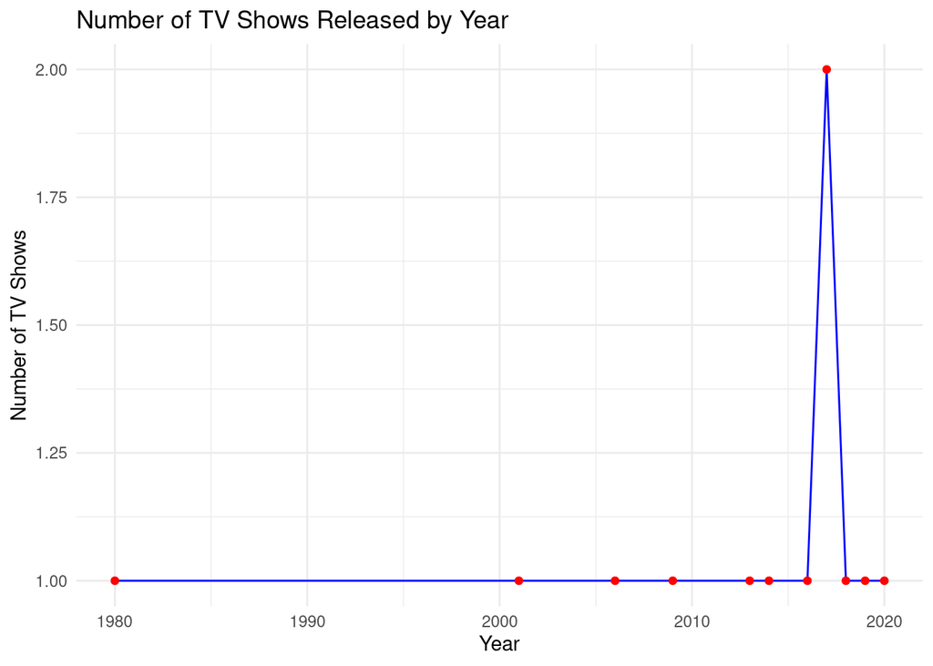

```r
library(ggplot2)

movies$year <- as.numeric(movies$year)
year_counts <- movies %>%
  filter(!is.na(year)) %>%
  count(year)

ggplot(year_counts, aes(x = year, y = n)) +
  geom_line(color = "blue") +
  geom_point(color = "red") +
  labs(title = "Number of TV Shows Released by Year",
       x = "Year",
       y = "Number of TV Shows") +
  theme_minimal()
```

```r
most_releases <- year_counts[which.max(year_counts$n), ]
print(most_releases)
```

```
##   year n
## 8 2017 2
```

AMAZON

Select 5 categories from Amazon and select 30 products from each category.

```r
library(polite)
library(kableExtra)
library(rmarkdown)
library(httr)
library(rvest)
library(dplyr)
library(stringr)
library(ggplot2)
```

```r
urls <- c('https://www.amazon.com/s?k=skin+care&crid=3FODLJK4URUE9&sprefix=skin%2Caps%2C510&ref=nb_sb_ss_ts-doa-p_1_4', 'https://www.amazon.com/s?k=perfume&crid=1MRC8YEDNO62V&sprefix=perfume%2Caps%2C397&ref=nb_sb_noss_1', 'https://www.amazon.com/s?k=bags+for+women&ref=nb_sb_noss', 'https://www.amazon.com/s?k=shoes&crid=QOEP1YQOC5W&sprefix=shoe%2Caps%2C1302&ref=nb_sb_noss_2', 'https://www.amazon.com/s?k=pants&ref=nb_sb_noss')

nameofproduct <- vector("list", length(urls))
price <- vector("list", length(urls))
description <- vector("list", length(urls))
Ratings <- vector("list", length(urls))
Reviews <- vector("list", length(urls))
```

```r
df <- list()

for (i in seq_along(urls)) {
    session <- bow(urls[i], user_agent = "Educational")
    webpage <- scrape(session)

nameofproduct[[i]] <-  webpage %>%
  html_nodes('.a-size-base-plus.a-color-base') %>%
  html_text() %>%
  head(30)

price[[i]] <-  webpage %>%
  html_nodes('.a-price-whole') %>%
  html_text() %>%
  head(30)

description[[i]] <-  webpage %>%
  html_nodes('.a-size-mini.a-spacing-none.a-color-base s-line-clamp-3') %>%
  html_text() %>%
  head(30)

Ratings[[i]] <-  webpage %>%
  html_nodes('.a-icon.a-icon-star-small.a-star-small-4-5') %>%
  html_text() %>%
  head(30)

Reviews[[i]] <-  webpage %>%
  html_nodes('.a-size-base-plus.a-color-base') %>%
  html_text() %>%
  head(30)
}
```

5. Extract the price, description, ratings and reviews of each product.

```r
skincare <- data.frame(nameofproduct[[1]],
                       Price = price[[1]],
                       Ratings = Ratings[[1]],
                       stringsAsFactors = FALSE
                       )
head(skincare, 50)
```

```
##                                                                                                                                                                              nameofproduct..1..
## 1                                                                                                                                                                                         COSRX
## 2                                               Snail Mucin 96% Power Face Serum 3.38 fl oz 100ml, Hydrating Serum for Face, Self Care, Glow Skin under Makeup, Korean Skin Care, Korean Beauty
## 3                                                                                                                                                                                        CeraVe
## 4      Moisturizing Cream | Body and Face Moisturizer for Dry Skin | Body Cream with Hyaluronic Acid and Ceramides | Daily Moisturizer | Oil-Free | Fragrance Free | Non-Comedogenic | 19 Ounce
## 5                                                                                                                                                                 Amazon's Choice: Overall Pick
## 6                                                                                                                                                                                Paula's Choice
## 7                                                                 SKIN PERFECTING 2% BHA Liquid Salicylic Acid Exfoliant-Facial Exfoliant for Blackheads, Enlarged Pores, Wrinkles & Fine Lines
## 8                                                                                                                                                                                        e.l.f.
## 9                                                     SKIN Hydrated Ever After Skincare Mini Kit, Cleanser, Makeup Remover, Moisturiser & Eye Cream For Hydrating Skin, Airplane-Friendly Sizes
## 10                                                                                                                                                                                      LANEIGE
## 11                                                                                        Lip Sleeping Mask: Nourish, Hydrate, Vitamin C, Murumuru & Shea Butter, Antioxidants, Flaky, Dry Lips
## 12                                                                                                                                                                                       CeraVe
## 13 Hydrating Facial Cleanser | Moisturizing Face Wash For Dry Skin | Hyaluronic Acid + Ceramides + Glycerin | Hydrating Cleanser For Normal To Dry Skin | National Eczema Association Certified
## 14                                                                                                                                                                                     BIODANCE
```

[output cut: 47 more lines]

```r
skincare %>%
    kable("latex", booktabs = TRUE) %>%
  kable_styling(latex_options = "scale_down")
```

```r
perfume <- data.frame(nameofproduct[[2]],
                       Price = price[[2]],
                       Ratings = Ratings[[2]],
                       stringsAsFactors = FALSE
                       )
head(perfume, 30)
```

```
##                                                                                                                                                                                       nameofproduct..2..
## 1                                                                                                                                                                          Amazon's Choice: Overall Pick
## 2                                                                                                                                        Lattafa Yara for Women Eau de Parfum Spray, 3.40 Ounce / 100 ml
## 3                                                                                                                                           Al-Rehab Choco Musk Eau de Parfum Spray for Women, 1.7 Ounce
## 4                                                                                                                               Versace Bright Crystal by Versace for Women 3.0 oz Eau de Toilette Spray
## 5                                                                                                                                Victoria's Secret Bare Vanilla Body Mist, Body Spray for Women (8.4 oz)
## 6                                                                                                                                     Dossier - Eau de Parfum - Ambery Vanilla - Feminine - 1.7Oz (50ml)
## 7                                                                                                                                                                                     Click to see price
## 8                                                                                Victoria's Secret Mini Eau de Parfum Discovery Gift Set: Bombshell, Bombshell Magic, Tease, Bare, Very Sexy, & Heavenly
## 9                                                                                      Lake & Skye 11 11 Eau de Parfum Travel Spray, Long Lasting Fragrance, 0.5 fl oz (15 ml) - Sheer & Uplifting Scent
## 10 Calvin Klein My Euphoria Eau de Parfum – Women's Ambery Floral Perfume – With Notes of Blackcurrant, Orchid Flambé, Black Sesame, Vanilla & Woods – Luxury Perfumes for Women– Long Lasting Fragrance
## 11                                                                     Vera Wang Eau de Parfum for Women - Delicate, Floral Scent - Notes of Iris, Lillies, & Sandalwood - Feminine & Subtle - 3.4 Fl Oz
## 12                                             Billie Eilish Eau de Parfum Spray Perfume for Women, Notes of Sugared Petals, Vanilla & Warm Musk, Amber Gourmand Fragrance, Long Lasting, Everyday Scent
## 13                                                                                                                             Vera Wang Princess Eau de Toilette Spray for Women, Vanilla, 3.4 Fl Ounce
## 14                                                                                                                KHADLAJ PERFUMES Hareem Al Sultan Gold Concentrated Perfume Oil for Unisex, 1.18 Ounce
```

[output cut: 47 more lines]

```r
perfume %>%
    kable("latex", booktabs = TRUE) %>%
  kable_styling(latex_options = "scale_down")
```

```r
bags <- data.frame(nameofproduct[[3]],
                       Price = price[[3]],
                       Ratings = Ratings[[3]],
                       stringsAsFactors = FALSE
                       )
head(bags, 30)
```

```
##                                                                                                                                                                              nameofproduct..3..
## 1                                                                                                                                                                 Amazon's Choice: Overall Pick
## 2                                                                                                                                                                                  Michael Kors
## 3                                                                                                                                                                     (マイケルコース Crossbody
## 4                                                                                                                                                                                      CYHTWSDJ
## 5                                                                                                         Shoulder Bags for Women, Cute Hobo Tote Handbag Mini Clutch Purse with Zipper Closure
## 6                                                                                                                                                                                  Michael Kors
## 7                                                                                                                                                                              Crossbody, Brown
## 8                                                                                                                                                                                      BAGSMART
## 9                                                                               Tote Bag for Women, Lightweight Puffy Tote Bag with Compartments, Quilted Shoulder Bag Handbag for Travel, Work
## 10                                                                                                                                                                                         ZHMO
## 11                                                                     Large Canvas Tote Bag for Women,Womens Laptop Work Book Bags Crossbody Purse Handbag Shoulder Travel Messenger Gym Totes
## 12                                                                                                                                                                                     TOPASION
## 13                                                                         Corduroy Tote Bag Cute Tote Bags for Women Shoulder Bag with Inner Pocket for Work Beach Travel and Shopping Grocery
## 14                                                                                                                                                                                 Michael Kors
```

[output cut: 47 more lines]

```r
bags %>%
    kable("latex", booktabs = TRUE) %>%
  kable_styling(latex_options = "scale_down")
```

```r
shoes <- data.frame(nameofproduct[[4]],
                       Price = price[[4]],
                       Ratings = Ratings[[4]],
                       stringsAsFactors = FALSE
                       )
head(shoes, 30)
```

```
##                                                                                                          nameofproduct..4..
## 1                                                                                             Amazon's Choice: Overall Pick
## 2                                                                                                              Under Armour
## 3                                                                                                   Men's Charged Assert 10
## 4                                                                                                                  Hey Dude
## 5                                    Men's Wally Stretch | Men's Loafers | Men's Slip On Shoes | Comfortable & Light-Weight
## 6                                                                                                               New Balance
## 7                                                                                 Men's 608 V5 Casual Comfort Cross Trainer
## 8                                                                                                                    adidas
## 9                                                                                                   Men's Daily 3.0 Sneaker
## 10                                                                                                              New Balance
## 11                                                                                                 Women's 574 Core Sneaker
## 12                                                                                                                    Crocs
## 13                                                                                                Unisex Adult Classic Clog
## 14                                                                                                                   adidas
```

[output cut: 47 more lines]

```r
shoes %>%
    kable("latex", booktabs = TRUE) %>%
  kable_styling(latex_options = "scale_down")
```

```r
pants <- data.frame(nameofproduct[[5]],
                       Price = price[[5]],
                       Ratings = Ratings[[5]],
                       stringsAsFactors = FALSE
                       )
head(pants, 30)
```

```
##                                                                                                   nameofproduct..5..
## 1                                                                                                     THE GYM PEOPLE
## 2                    Thick High Waist Yoga Pants with Pockets, Tummy Control Workout Running Yoga Leggings for Women
## 3                                                                                      Amazon's Choice: Overall Pick
## 4                                                                                                Wrangler Authentics
## 5                                                                               Men's Relaxed Fit Stretch Cargo Pant
## 6                                                                                                            TNNZEET
## 7  High Waisted Leggings for Women - No See Through Tummy Control Cycling Workout Yoga Pants with Pockets Reg & Plus
## 8                                                                                                  Fruit of the Loom
## 9                  Eversoft Fleece Elastic Bottom Sweatpants with Pockets, Relaxed Fit, Moisture Wicking, Breathable
## 10                                                                                                             Hanes
## 11                                                                      ComfortSoft EcoSmart Men's Fleece Sweatpants
## 12                                                                                                 Ultra Performance
## 13                                    3 Pack Fleece Active Tech Joggers for Men, Mens Sweatpants with Zipper Pockets
## 14                                                                                                          Champion
```

[output cut: 47 more lines]

```r
pants %>%
    kable("latex", booktabs = TRUE) %>%
  kable_styling(latex_options = "scale_down")
```

6. Describe the data you have extracted.

The extracted dataset contains key details about products across five categories: Skincare, Perfume, Bags, Shoes, and Pants. Here’s an overview:

Price: Numerical values indicating the price, cleaned and standardized for analysis.

Ratings: Average star ratings (1 to 5) given by customers, reflecting product quality or satisfaction.

Category: A label indicating which category the product belongs to.

The data reveals insights into product characteristics and consumer feedback, aiding in trend analysis and decision-making.

7. What will be your use case for the data you have extracted?

The extracted data can be applied in several practical contexts:

Market Analysis:

-Identifying price trends and outliers in each category.

-Analyzing consumer preferences based on product ratings and reviews.

Customer Insights:

-Recommending products with the best quality-price ratio. Highlighting top-rated or most affordable products in each category.

Retail Strategies: -Informing inventory stocking by analyzing trends in popular products.

-Pricing strategies for competitive positioning.

Visualization and Reporting:

-Using the data to create visual insights for presentations or reports.

8. Create graphs regarding the use case. And briefly explain it.

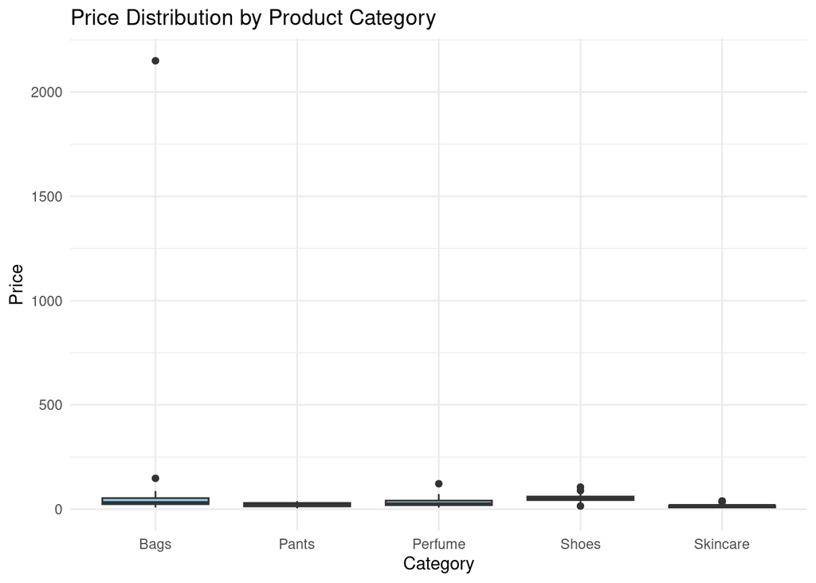

```r
category_names <- c("Skincare", "Perfume", "Bags", "Shoes", "Pants")
all_data <- bind_rows(
  skincare %>% mutate(Category = "Skincare"),
  perfume %>% mutate(Category = "Perfume"),
  bags %>% mutate(Category = "Bags"),
  shoes %>% mutate(Category = "Shoes"),
  pants %>% mutate(Category = "Pants")
)

all_data$Price <- as.numeric(gsub(",", "", all_data$Price))

ggplot(all_data, aes(x = Category, y = Price)) +
  geom_boxplot(fill = "skyblue") +
  labs(title = "Price Distribution by Product Category", x = "Category", y = "Price") +
  theme_minimal()
```

The boxplot visualizes the distribution of product prices across categories.

Insights:

-The spread of prices varies significantly by category. -Categories like Bags and Shoes may have higher median prices and broader ranges compared to Skincare or Perfume.

9. Graph the price and the ratings for each category. Use basic plotting functions and ggplot2 package.

[figure not shown]

```r
ggplot(all_data, aes(x = Price, y = as.numeric(Ratings))) +
  geom_point(aes(color = Category), size = 2) +
  labs(title = "Price vs Ratings by Category", x = "Price", y = "Ratings") +
  theme_minimal() +
  facet_wrap(~ Category, scales = "free")
```

Explanation:

-The relationship is plotted per category using facet_wrap.

10. Rank the products of each category by price and ratings. Explain briefly.

```r
skincare$Price <- as.numeric(gsub(",", "", skincare$Price))
perfume$Price <- as.numeric(gsub(",", "", perfume$Price))
bags$Price <- as.numeric(gsub(",", "", bags$Price))
shoes$Price <- as.numeric(gsub(",", "", shoes$Price))
pants$Price <- as.numeric(gsub(",", "", pants$Price))

skincare_ranked <- skincare %>% arrange(desc(Price), desc(Ratings))
perfume_ranked <- perfume %>% arrange(desc(Price), desc(Ratings))
bags_ranked <- bags %>% arrange(desc(Price), desc(Ratings))
shoes_ranked <- shoes %>% arrange(desc(Price), desc(Ratings))
pants_ranked <- pants %>% arrange(desc(Price), desc(Ratings))
```

```r
head(skincare_ranked, 30)
```

```
##                                                                                                                                                                              nameofproduct..1..
## 1                                                                                                                                                                                La Roche-Posay
## 2                                                                                                                                                                                La Roche-Posay
## 3                                                                                                                                                                                        CeraVe
## 4                                                                                                                                                                 Amazon's Choice: Overall Pick
## 5                                                                                                                                                                                         COSRX
## 6      Moisturizing Cream | Body and Face Moisturizer for Dry Skin | Body Cream with Hyaluronic Acid and Ceramides | Daily Moisturizer | Oil-Free | Fragrance Free | Non-Comedogenic | 19 Ounce
## 7                                                                 SKIN PERFECTING 2% BHA Liquid Salicylic Acid Exfoliant-Facial Exfoliant for Blackheads, Enlarged Pores, Wrinkles & Fine Lines
## 8                             Under Eye Patches - 30 Pairs - 24K Gold Eye Mask- Puffy Eyes & Dark Circles Treatments,Reduce Under Eye Bags and Smooth Wrinkles,Eye Skin Care Pads With Collagen
## 9                                                                                         Lip Sleeping Mask: Nourish, Hydrate, Vitamin C, Murumuru & Shea Butter, Antioxidants, Flaky, Dry Lips
## 10                                                Snail Mucin 92% Face Moisturizer, 3.52 Oz, Lightweight Moisturing Cream for Soft, Glowy Skin, Korean Skin Care, Korean Moisturizer Face Cream
## 11                                              Snail Mucin 96% Power Face Serum 3.38 fl oz 100ml, Hydrating Serum for Face, Self Care, Glow Skin under Makeup, Korean Skin Care, Korean Beauty
## 12                                                                                                                                                                                       CeraVe
## 13                                                         Heartleaf Pore Control Cleansing Oil, Oil Cleanser for Face, Makeup Blackhead Remover, Korean Skin Care 6.76 fl oz(200ml) (original)
## 14                                                                            Bio-Collagen Real Deep Mask, Hydrating Overnight Hydrogel Mask, Pore Minimizing, Elasticity Improvement, 34g x4ea
```

[output cut: 47 more lines]

```r
skincare_ranked %>%
    kable("latex", booktabs = TRUE) %>%
  kable_styling(latex_options = "scale_down")
```

```r
head(perfume_ranked, 30)
```

```
##                                                                                                                                                                                       nameofproduct..2..
## 1                                                                                                                                              Lattafa Yara Moi Eau de Parfum Spray for Women, 3.4 Ounce
## 2                                                                                              Lucky You Perfume for Women, Eau De Toilette Day or Night Spray with Fresh Flower Citrus Scent, 3.4 fl oz
## 3                                                                                                                                Victoria's Secret Bare Vanilla Body Mist, Body Spray for Women (8.4 oz)
## 4                                                                                                                                              Lattafa Rave Now Eau de Parfum Spray for Women, 3.4 Ounce
## 5                                                                                                                                     Dossier - Eau de Parfum - Ambery Vanilla - Feminine - 1.7Oz (50ml)
## 6                                                                                                                               Versace Bright Crystal by Versace for Women 3.0 oz Eau de Toilette Spray
## 7  Calvin Klein My Euphoria Eau de Parfum – Women's Ambery Floral Perfume – With Notes of Blackcurrant, Orchid Flambé, Black Sesame, Vanilla & Woods – Luxury Perfumes for Women– Long Lasting Fragrance
## 8                                                                                Victoria's Secret Mini Eau de Parfum Discovery Gift Set: Bombshell, Bombshell Magic, Tease, Bare, Very Sexy, & Heavenly
## 9                                                                                                                                        Lattafa Perfumes Asad for Unisex Eau de Parfum Spray, 3.4 Ounce
## 10                                                                                                                                                                                    Click to see price
## 11                                                                                                                KHADLAJ PERFUMES Hareem Al Sultan Gold Concentrated Perfume Oil for Unisex, 1.18 Ounce
## 12                                                                     Vera Wang Eau de Parfum for Women - Delicate, Floral Scent - Notes of Iris, Lillies, & Sandalwood - Feminine & Subtle - 3.4 Fl Oz
## 13                                                                                     Lake & Skye 11 11 Eau de Parfum Travel Spray, Long Lasting Fragrance, 0.5 fl oz (15 ml) - Sheer & Uplifting Scent
## 14                                                                                                                                                    Armaf Club De Nuit EDP Spray Women 3.6 oz, Scandal
```

[output cut: 47 more lines]

```r
perfume_ranked %>%
    kable("latex", booktabs = TRUE) %>%
  kable_styling(latex_options = "scale_down")
```

```r
head(bags_ranked, 30)
```

```
##                                                                                                                                                                              nameofproduct..3..
## 1                                                                                                                                                                                  Montana West
## 2                                                                                                                                                                                      TOPASION
## 3                                                                                                                                         Charlotte Large 3-in-1 Tote Crossbody Handbag Leather
## 4                                                                      Large Canvas Tote Bag for Women,Womens Laptop Work Book Bags Crossbody Purse Handbag Shoulder Travel Messenger Gym Totes
## 5                                                                                                                                                      Jet Set Travel Medium Logo Crossbody Bag
## 6                                                                               Tote Bag for Women, Lightweight Puffy Tote Bag with Compartments, Quilted Shoulder Bag Handbag for Travel, Work
## 7                                                                                                                                                                     (マイケルコース Crossbody
## 8                                                                                                         Shoulder Bags for Women, Cute Hobo Tote Handbag Mini Clutch Purse with Zipper Closure
## 9                                                                                                                                                                                       Taygeer
## 10                                                                               Color-Block Crossbody Bags for Women Leather Cross Body Purses Cute Designer Handbags Shoulder Bag Medium Size
## 11                                                                                                                                                                                      Kipling
## 12                                                                                                  Purses and Handbags for Women Tote Purse and Wallet Set Shoulder Satchel Bag for Women 3PCS
## 13                                                                                                                                                                                 Michael Kors
## 14                                                                                                                                                                                 Michael Kors
```

[output cut: 47 more lines]

```r
bags_ranked %>%
    kable("latex", booktabs = TRUE) %>%
  kable_styling(latex_options = "scale_down")
```

```r
head(shoes_ranked, 30)
```

```
##                                                                                                          nameofproduct..4..
## 1                                                                      Unisex-Adult Bistro Clogs, Slip Resistant Work Shoes
## 2                                    Men's Wally Stretch | Men's Loafers | Men's Slip On Shoes | Comfortable & Light-Weight
## 3                                                                                                                  Skechers
## 4                                                                                                    Men's Afterburn M. Fit
## 5                                                                                        Men's Lite Racer Adapt 7.0 Sneaker
## 6                                                                                                   Men's Charged Assert 10
## 7                                                                                                                Bruno Marc
## 8                                                                                                               New Balance
## 9                                                                                                                    Levi's
## 10                                                                                                                    Bloch
## 11                                                                                            Amazon's Choice: Overall Pick
## 12                                                                                                                 Skechers
## 13                                                                                                                   adidas
## 14                                                                                                                    Crocs
```

[output cut: 47 more lines]

```r
shoes_ranked %>%
    kable("latex", booktabs = TRUE) %>%
  kable_styling(latex_options = "scale_down")
```

```r
head(pants_ranked, 30)
```

```
##                                                                                                   nameofproduct..5..
## 1                                                                                                  Ultra Performance
## 2                                                            Women's Ultra Lux Comfort with Flex Motion Trouser Pant
## 3                                                                                                            TNNZEET
## 4                                                                                               The Children's Place
## 5                                                                                                Wrangler Authentics
## 6  Mens 3 Pack Fleece Active Athletic Workout Jogger Sweatpants for Men with Zipper Pocket and Drawstring Size S-3XL
## 7                                                                       ComfortSoft EcoSmart Men's Fleece Sweatpants
## 8                                                                                                  Fruit of the Loom
## 9                          Men's Pants, Lightweight Open-Hem Lounge Pants for Men, Jersey Pants (Reg. or Big & Tall)
## 10                                                                                                               Lee
## 11                                                              Authentics Men's Regular Fit Comfort Flex Waist Jean
## 12                                                                                           Men's Woven Vital Pants
## 13                                                                                                 Fruit of the Loom
## 14                   Thick High Waist Yoga Pants with Pockets, Tummy Control Workout Running Yoga Leggings for Women
```

[output cut: 47 more lines]

```r
pants_ranked %>%
    kable("latex", booktabs = TRUE) %>%
  kable_styling(latex_options = "scale_down")
```

High Price + High Rating: Products ranked at the top of each list with high prices and ratings are generally regarded as premium and popular choices within the category. Lower Price + High Rating: Products with lower prices but high ratings indicate affordable yet well-received options, highlighting value for money.